# Data Analytics Project

```python
Low_Annual_Income
```

|  | Customer_ID | Customer_Name | Age | Gender | Marital_Status | Education_Level | Employment_Status | Occupation | Annual_Income | Monthly_Income | ... | Total_Deposits | Total_Withdrawals | Average_Monthly_Balance | Missed_EMI_Count | Days_Past_Due | Outstanding_Loan_Balance | Fraud_Flag | Risk_Category | Recovery_Status | Loan_Default |
| --- | --- | --- | --- | --- | --- | --- | --- | --- | --- | --- | --- | --- | --- | --- | --- | --- | --- | --- | --- | --- | --- |
| 2 | CUST100002 | Rahul Sharma | 29 | Male | Single | Graduate | Employed | Engineer | 54003 | 4503 | ... | 8002 | 7001 | 6497 | 4 | -1 | 19997 | No | High | Ongoing | Yes |
| 3 | CUST100003 | Pooja Singh | 36 | Female | Married | Graduate | Employed | Nurse | 69116 | 5765 | ... | 10099 | 8749 | 12105 | 4 | 11 | 26301 | No | Medium | Not Required | No |
| 4 | CUST100004 | Arjun Patel | 22 | Male | Married | Graduate | Employed | Business | 58319 | 4857 | ... | 8596 | 7500 | 8099 | -2 | 35 | 21798 | No | High | Ongoing | Yes |
| 5 | CUST100005 | Priya Reddy | 21 | Female | Married | Graduate | Employed | Analyst | 56164 | 4684 | ... | 8297 | 7247 | 7298 | -4 | 18 | 20899 | No | High | Ongoing | Yes |
| 6 | CUST100006 | Pooja Singh | 27 | Female | Married | Graduate | Employed | Nurse | 69115 | 5761 | ... | 10095 | 8753 | 12101 | -2 | 12 | 26295 | No | Medium | Not Required | No |
| ... | ... | ... | ... | ... | ... | ... | ... | ... | ... | ... | ... | ... | ... | ... | ... | ... | ... | ... | ... | ... | ... |
| 4995 | CUST104995 | Pooja Singh | 28 | Female | Married | Graduate | Employed | Nurse | 69122 | 5759 | ... | 10095 | 8749 | 12100 | 3 | 11 | 26301 | No | Medium | Not Required | No |
| 4996 | CUST104996 | Mohan Rao | 29 | Male | Single | Graduate | Employed | Shop Owner | 66962 | 5580 | ... | 9803 | 8496 | 11298 | -5 | -3 | 25399 | No | Medium | Not Required | No |
| 4997 | CUST104997 | Sneha Nair | 24 | Female | Single | Graduate | Employed | Teacher | 60483 | 5035 | ... | 8900 | 7754 | 8898 | 1 | -3 | 22703 | No | High | Ongoing | Yes |
| 4998 | CUST104998 | Rahul Sharma | 22 | Male | Single | Graduate | Employed | Engineer | 53999 | 4505 | ... | 8003 | 6999 | 6503 | -5 | -2 | 19997 | No | High | Ongoing | Yes |
| 4999 | CUST104999 | Sneha Nair | 31 | Female | Single | Graduate | Employed | Teacher | 60477 | 5035 | ... | 8899 | 7755 | 8897 | 2 | 3 | 22696 | No | High | Ongoing | Yes |

2557 rows × 37 columns

```python
def performance(Annual_Income):
    if Annual_Income >= 500000:
        return "High"
    elif Annual_Income >= 200000:
        return "Medium"
    else:
        return "Low"

df['performance'] = df['Annual_Income'].apply(performance)
```

```python
df
```

|  | Customer_ID | Customer_Name | Age | Gender | Marital_Status | Education_Level | Employment_Status | Occupation | Annual_Income | Monthly_Income | ... | Total_Withdrawals | Average_Monthly_Balance | Missed_EMI_Count | Days_Past_Due | Outstanding_Loan_Balance | Fraud_Flag | Risk_Category | Recovery_Status | Loan_Default | performance |
| --- | --- | --- | --- | --- | --- | --- | --- | --- | --- | --- | --- | --- | --- | --- | --- | --- | --- | --- | --- | --- | --- |
| 0 | CUST100000 | Sneha Kapoor | 40 | Female | Married | Graduate | Employed | Tester | 95035 | 7918 | ... | 11750 | 21704 | 3 | 12 | 37105 | No | Low | Not Required | No | Low |
| 1 | CUST100001 | Aishwarya Rao | 41 | Female | Married | Graduate | Employed | Bank Officer | 82085 | 6841 | ... | 10254 | 16897 | 3 | 13 | 31702 | No | Low | Not Required | No | Low |
| 2 | CUST100002 | Rahul Sharma | 29 | Male | Single | Graduate | Employed | Engineer | 54003 | 4503 | ... | 7001 | 6497 | 4 | -1 | 19997 | No | High | Ongoing | Yes | Low |
| 3 | CUST100003 | Pooja Singh | 36 | Female | Married | Graduate | Employed | Nurse | 69116 | 5765 | ... | 8749 | 12105 | 4 | 11 | 26301 | No | Medium | Not Required | No | Low |
| 4 | CUST100004 | Arjun Patel | 22 | Male | Married | Graduate | Employed | Business | 58319 | 4857 | ... | 7500 | 8099 | -2 | 35 | 21798 | No | High | Ongoing | Yes | Low |
| ... | ... | ... | ... | ... | ... | ... | ... | ... | ... | ... | ... | ... | ... | ... | ... | ... | ... | ... | ... | ... | ... |
| 4995 | CUST104995 | Pooja Singh | 28 | Female | Married | Graduate | Employed | Nurse | 69122 | 5759 | ... | 8749 | 12100 | 3 | 11 | 26301 | No | Medium | Not Required | No | Low |
| 4996 | CUST104996 | Mohan Rao | 29 | Male | Single | Graduate | Employed | Shop Owner | 66962 | 5580 | ... | 8496 | 11298 | -5 | -3 | 25399 | No | Medium | Not Required | No | Low |
| 4997 | CUST104997 | Sneha Nair | 24 | Female | Single | Graduate | Employed | Teacher | 60483 | 5035 | ... | 7754 | 8898 | 1 | -3 | 22703 | No | High | Ongoing | Yes | Low |
| 4998 | CUST104998 | Rahul Sharma | 22 | Male | Single | Graduate | Employed | Engineer | 53999 | 4505 | ... | 6999 | 6503 | -5 | -2 | 19997 | No | High | Ongoing | Yes | Low |
| 4999 | CUST104999 | Sneha Nair | 31 | Female | Single | Graduate | Employed | Teacher | 60477 | 5035 | ... | 7755 | 8897 | 2 | 3 | 22696 | No | High | Ongoing | Yes | Low |

5000 rows × 38 columns

```python
statistical_summary= df.describe()
```

```python
statistical_summary
```

|  | Age | Annual_Income | Monthly_Income | Monthly_Expenses | Savings_Balance | Account_Balance | Credit_Score | Credit_History_Years | Existing_EMI | Debt_to_Income_Ratio | ... | Interest_Rate | EMI_Amount | Collateral_Value | Monthly_Transaction_Count | Total_Deposits | Total_Withdrawals | Average_Monthly_Balance | Missed_EMI_Count | Days_Past_Due | Outstanding_Loan_Balance |
| --- | --- | --- | --- | --- | --- | --- | --- | --- | --- | --- | --- | --- | --- | --- | --- | --- | --- | --- | --- | --- | --- |
| count | 5000.000000 | 5000.000000 | 5000.000000 | 5000.000000 | 5000.00000 | 5000.00000 | 5000.000000 | 5000.000000 | 5000.000000 | 5000.000000 | ... | 5000.000000 | 5000.000000 | 5000.00000 | 5000.000000 | 5000.000000 | 5000.000000 | 5000.000000 | 5000.000000 | 5000.000000 | 5000.000000 |
| mean | 34.418800 | 74284.540000 | 6190.411600 | 3345.215800 | 21269.18580 | 14512.75680 | 702.212200 | 7.483400 | 437.763400 | 6.959280 | ... | 9.977972 | 437.831000 | 96955.03240 | 39.398000 | 10817.344200 | 9347.739600 | 14012.799800 | 0.829200 | 14.070200 | 28451.924600 |
| std | 6.583986 | 12525.787412 | 1043.844122 | 521.941746 | 6958.76897 | 4639.17939 | 75.457264 | 4.272397 | 116.095169 | 0.738828 | ... | 1.365942 | 115.975018 | 28994.85866 | 6.579351 | 1739.729248 | 1449.763224 | 4639.193067 | 3.268664 | 12.434058 | 5219.070916 |
| min | 20.000000 | 53995.000000 | 4495.000000 | 2495.000000 | 9995.00000 | 6995.00000 | 575.000000 | -2.000000 | 245.000000 | 5.320000 | ... | 7.600000 | 245.000000 | 49995.00000 | 25.000000 | 7995.000000 | 6995.000000 | 6495.000000 | -5.000000 | -5.000000 | 19995.000000 |
| 25% | 29.000000 | 62643.000000 | 5223.000000 | 2863.000000 | 14803.00000 | 10203.00000 | 635.000000 | 4.000000 | 333.000000 | 6.387500 | ... | 8.860000 | 333.000000 | 70003.00000 | 34.000000 | 9203.000000 | 8003.000000 | 9703.000000 | -2.000000 | 2.000000 | 23603.000000 |
| 50% | 34.000000 | 73443.000000 | 6123.000000 | 3313.000000 | 20804.00000 | 14203.00000 | 700.500000 | 8.000000 | 433.500000 | 7.050000 | ... | 9.880000 | 433.000000 | 95003.00000 | 39.000000 | 10703.000000 | 9253.000000 | 13704.000000 | 1.000000 | 14.000000 | 28103.000000 |
| 75% | 39.000000 | 86395.000000 | 7195.000000 | 3845.000000 | 27995.00000 | 18995.00000 | 770.000000 | 11.000000 | 545.000000 | 7.570000 | ... | 11.110000 | 545.000000 | 124995.00000 | 44.000000 | 12495.000000 | 10745.000000 | 18495.000000 | 4.000000 | 26.000000 | 33495.000000 |
| max | 49.000000 | 95045.000000 | 7925.000000 | 4215.000000 | 32805.00000 | 22205.00000 | 832.000000 | 17.000000 | 635.000000 | 8.400000 | ... | 12.810000 | 635.000000 | 145005.00000 | 54.000000 | 13705.000000 | 11755.000000 | 21705.000000 | 7.000000 | 35.000000 | 37105.000000 |

8 rows × 23 columns

```python
import pandas as pd
import matplotlib.pyplot as plt
df = pd.read_csv("Finance_Analytics_5000_Rows.csv")
```

### Box Plot

```
Numerical Columns:
Index(['Age', 'Annual_Income', 'Monthly_Income', 'Monthly_Expenses',
       'Savings_Balance', 'Account_Balance', 'Credit_Score',
       'Credit_History_Years', 'Existing_EMI', 'Debt_to_Income_Ratio',
       'Number_of_Credit_Cards', 'Previous_Defaults', 'Loan_Term',
       'Interest_Rate', 'EMI_Amount', 'Collateral_Value',
       'Monthly_Transaction_Count', 'Total_Deposits', 'Total_Withdrawals',
       'Average_Monthly_Balance', 'Missed_EMI_Count', 'Days_Past_Due',
       'Outstanding_Loan_Balance'],
      dtype='object')
```

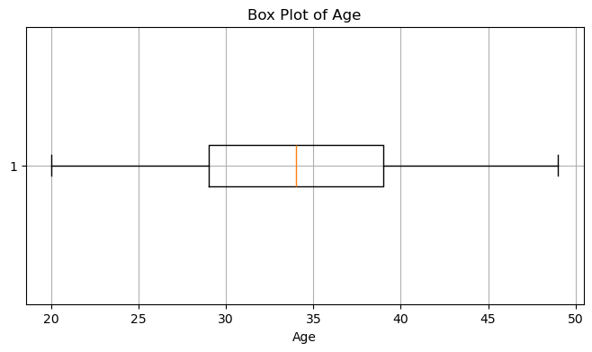

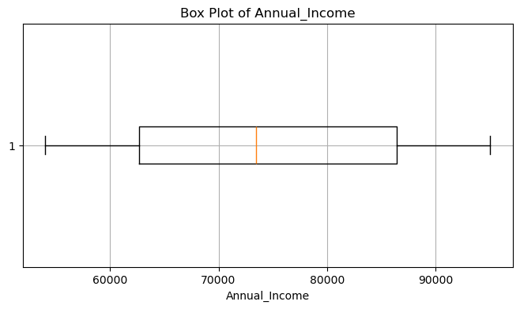

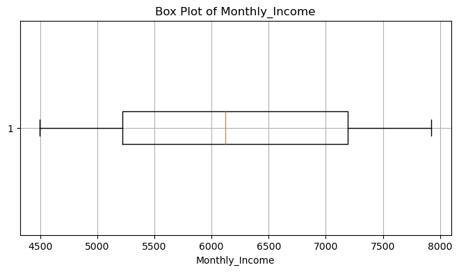

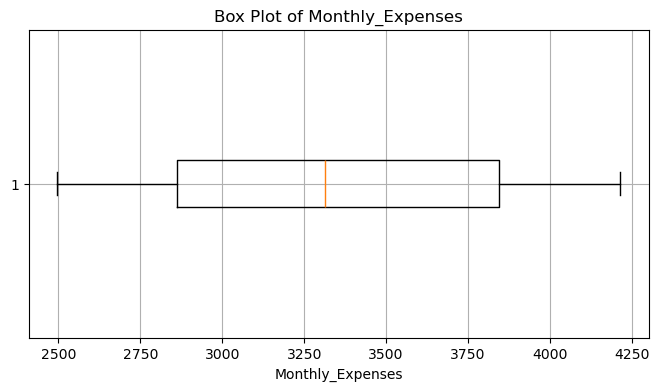

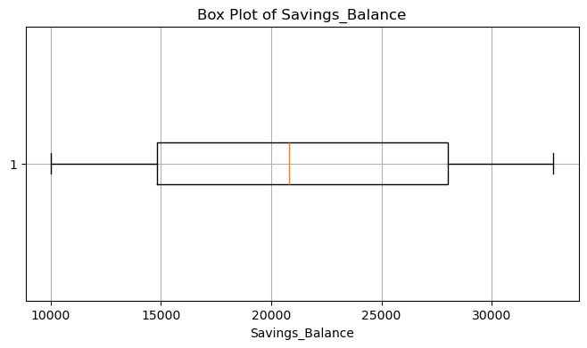

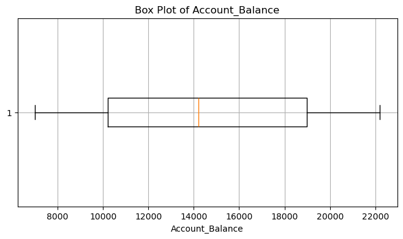

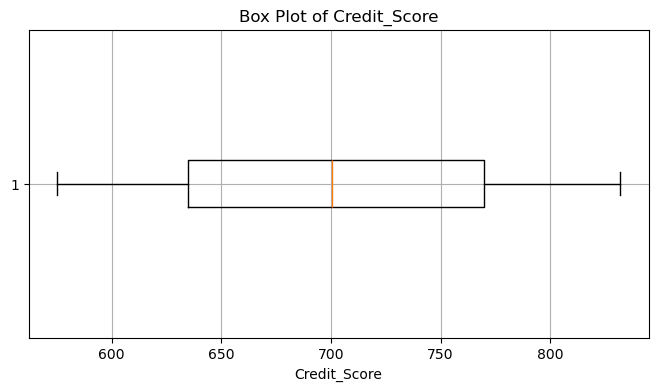

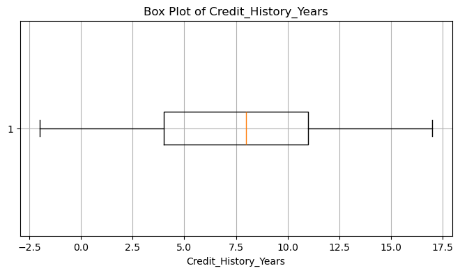

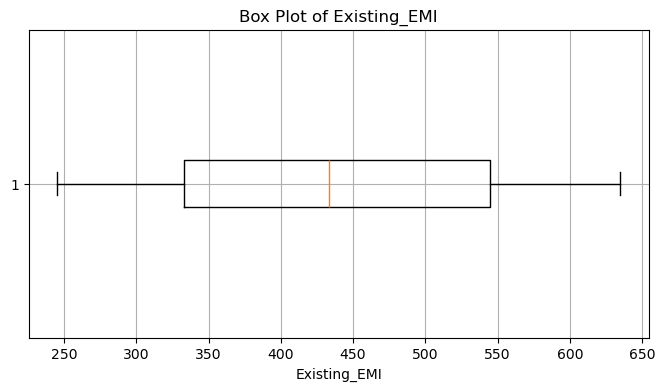

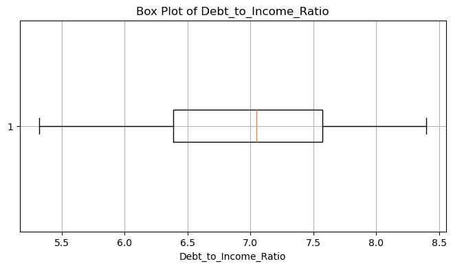

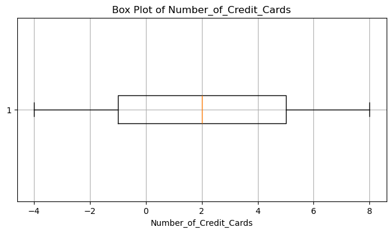

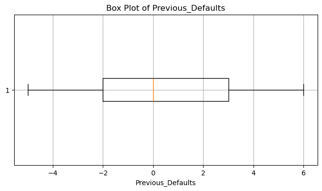

[11 more figures not shown]

```python
import pandas as pd
import matplotlib.pyplot as plt
df = pd.read_csv("Finance_Analytics_5000_Rows.csv")
numeric_cols = df.select_dtypes(include=['int64', 'float64']).columns
print("Numerical Columns:")
print(numeric_cols)
for col in numeric_cols:
    plt.figure(figsize=(8, 4))
    plt.boxplot(df[col].dropna(), vert=False)
    plt.title(f'Box Plot of {col}')
    plt.xlabel(col)
    plt.grid(True)
    plt.show()
```

### Bar Chart

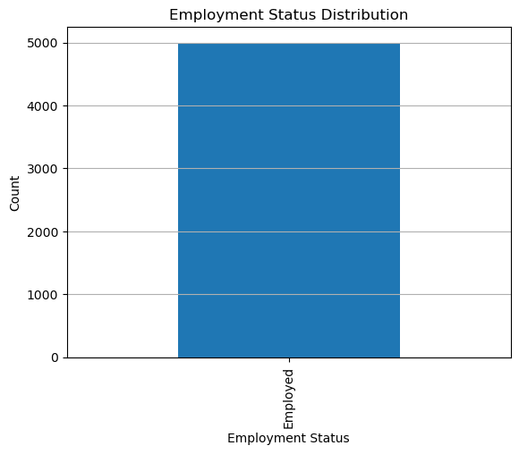

```python
import pandas as pd
import matplotlib.pyplot as plt

df = pd.read_csv("Finance_Analytics_5000_Rows.csv")

df['Employment_Status'].value_counts().plot(kind='bar')

plt.title("Employment Status Distribution")
plt.xlabel("Employment Status")
plt.ylabel("Count")
plt.grid(axis='y')

plt.show()
```

#### Bar Chart for Fraud Flag

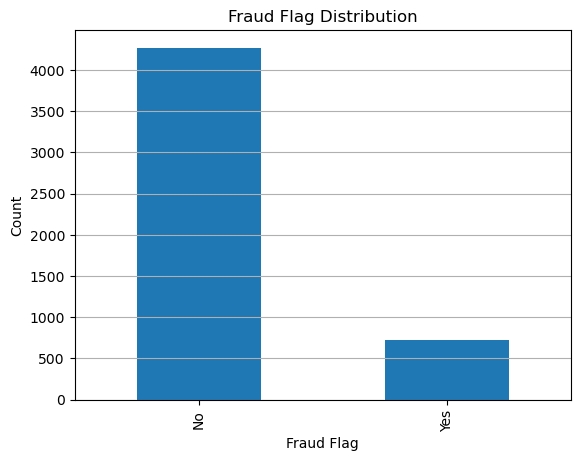

```python
import pandas as pd
import matplotlib.pyplot as plt

df = pd.read_csv("Finance_Analytics_5000_Rows.csv")

df['Fraud_Flag'].value_counts().plot(kind='bar')

plt.title("Fraud Flag Distribution")
plt.xlabel("Fraud Flag")
plt.ylabel("Count")
plt.grid(axis='y')

plt.show()
```

#### Bar Chart for Recovery Status

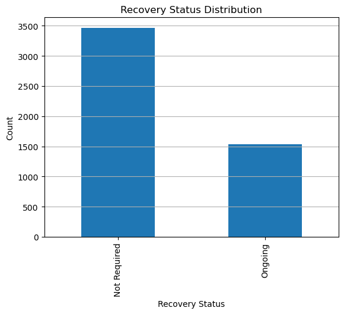

```python
import pandas as pd
import matplotlib.pyplot as plt

df = pd.read_csv("Finance_Analytics_5000_Rows.csv")

df['Recovery_Status'].value_counts().plot(kind='bar')

plt.title("Recovery Status Distribution")
plt.xlabel("Recovery Status")
plt.ylabel("Count")
plt.grid(axis='y')

plt.show()
```

#### Bar Chart for Risk Category

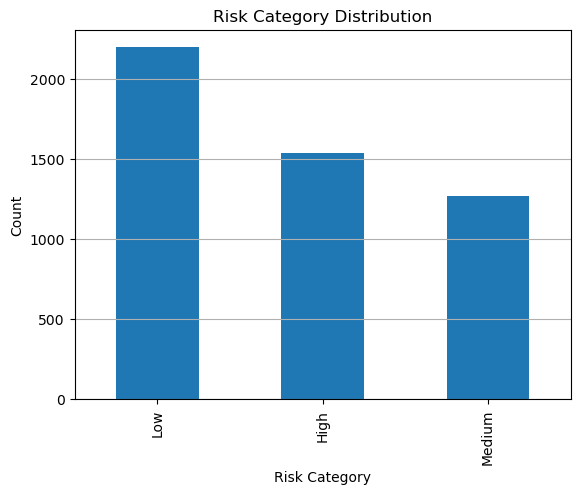

```python
import pandas as pd
import matplotlib.pyplot as plt

df = pd.read_csv("Finance_Analytics_5000_Rows.csv")

df['Risk_Category'].value_counts().plot(kind='bar')

plt.title("Risk Category Distribution")
plt.xlabel("Risk Category")
plt.ylabel("Count")
plt.grid(axis='y')

plt.show()
```

#### Bar Chart for Loan Purpose

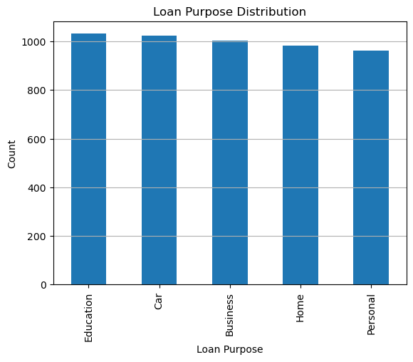

```python
import pandas as pd
import matplotlib.pyplot as plt

df = pd.read_csv("Finance_Analytics_5000_Rows.csv")

df['Loan_Purpose'].value_counts().plot(kind='bar')

plt.title("Loan Purpose Distribution")
plt.xlabel("Loan Purpose")
plt.ylabel("Count")
plt.grid(axis='y')

plt.show()
```

#### Bar Chart for Education Level

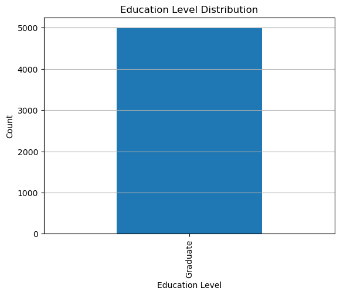

```python
import pandas as pd
import matplotlib.pyplot as plt

df = pd.read_csv("Finance_Analytics_5000_Rows.csv")

df['Education_Level'].value_counts().plot(kind='bar')

plt.title("Education Level Distribution")
plt.xlabel("Education Level")
plt.ylabel("Count")
plt.grid(axis='y')

plt.show()
```

#### Bar Chart for Gender

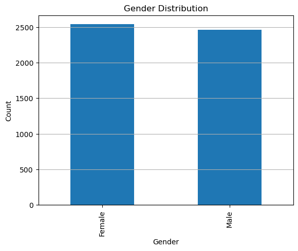

```python
import pandas as pd
import matplotlib.pyplot as plt

df = pd.read_csv("Finance_Analytics_5000_Rows.csv")

df['Gender'].value_counts().plot(kind='bar')

plt.title("Gender Distribution")
plt.xlabel("Gender")
plt.ylabel("Count")
plt.grid(axis='y')

plt.show()
```

### Pie Chart

#### Pie Chart for Gender

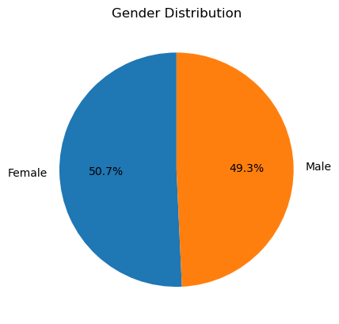

```python
import pandas as pd
import matplotlib.pyplot as plt

df = pd.read_csv("Finance_Analytics_5000_Rows.csv")

df['Gender'].value_counts().plot(
    kind='pie',
    autopct='%1.1f%%',
    startangle=90
)

plt.title("Gender Distribution")
plt.ylabel("")
plt.show()
```

#### Pie Chart for Employment Status

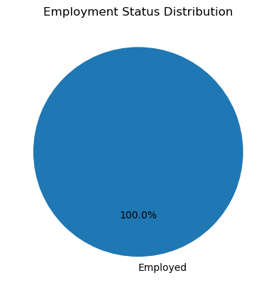

```python
import pandas as pd
import matplotlib.pyplot as plt

df = pd.read_csv("Finance_Analytics_5000_Rows.csv")

df['Employment_Status'].value_counts().plot(
    kind='pie',
    autopct='%1.1f%%',
    startangle=90
)

plt.title("Employment Status Distribution")
plt.ylabel("")
plt.show()
```

#### Pie Chart for Education Level

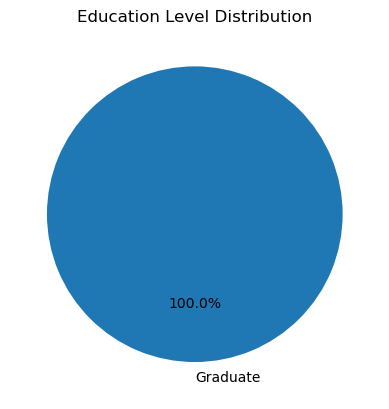

```python
import pandas as pd
import matplotlib.pyplot as plt

df = pd.read_csv("Finance_Analytics_5000_Rows.csv")

df['Education_Level'].value_counts().plot(
    kind='pie',
    autopct='%1.1f%%',
    startangle=90
)

plt.title("Education Level Distribution")
plt.ylabel("")
plt.show()
```

#### Pie Chart for Loan Purpose

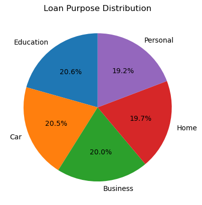

```python
import pandas as pd
import matplotlib.pyplot as plt

df = pd.read_csv("Finance_Analytics_5000_Rows.csv")

df['Loan_Purpose'].value_counts().plot(
    kind='pie',
    autopct='%1.1f%%',
    startangle=90
)

plt.title("Loan Purpose Distribution")
plt.ylabel("")
plt.show()
```

#### Pie Chart for Risk Category

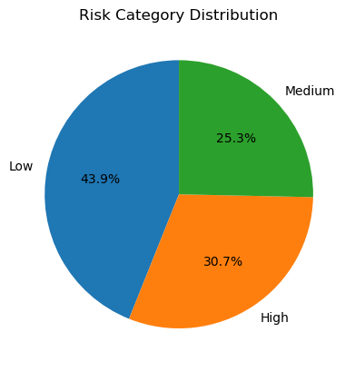

```python
import pandas as pd
import matplotlib.pyplot as plt

df = pd.read_csv("Finance_Analytics_5000_Rows.csv")

df['Risk_Category'].value_counts().plot(
    kind='pie',
    autopct='%1.1f%%',
    startangle=90
)

plt.title("Risk Category Distribution")
plt.ylabel("")
plt.show()
```

#### Pie Chart for Fraud Flag

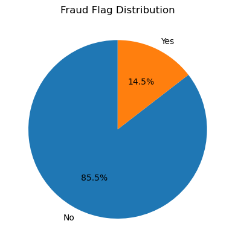

```python
import pandas as pd
import matplotlib.pyplot as plt

df = pd.read_csv("Finance_Analytics_5000_Rows.csv")

df['Fraud_Flag'].value_counts().plot(
    kind='pie',
    autopct='%1.1f%%',
    startangle=90
)

plt.title("Fraud Flag Distribution")
plt.ylabel("")
plt.show()
```

#### Pie Chart for Recovery Status

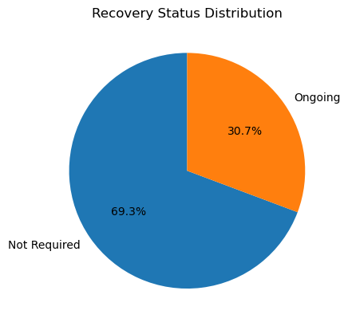

```python
import pandas as pd
import matplotlib.pyplot as plt

df = pd.read_csv("Finance_Analytics_5000_Rows.csv")

df['Recovery_Status'].value_counts().plot(
    kind='pie',
    autopct='%1.1f%%',
    startangle=90
)

plt.title("Recovery Status Distribution")
plt.ylabel("")
plt.show()
```

#### Outliers

Outliers are data values that are much higher or much lower than the rest of the data. They are unsual observation that do not follow the normal pattern of the dataset.

#### Examples:

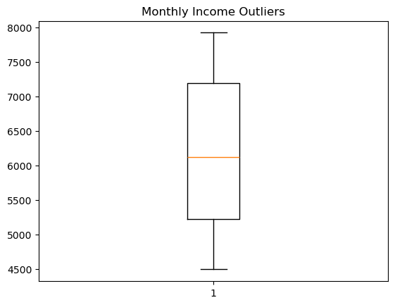

```python
import pandas as pd
import matplotlib.pyplot as plt

df = pd.read_csv("Finance_Analytics_5000_Rows.csv")

plt.boxplot(df["Monthly_Income"])
plt.title("Monthly Income Outliers")
plt.show()
```

### Day-2

### Restate the problem and success metrics

Financial institations process thousands of loans applications every day. This project analyzes customer demographics, income, credit history, banking transaction and loan details to identify high-risk customer Reduce non-performing assets(NPAs)

### Ensumerate dataset files

```python
import pandas as pd

df = pd.read_csv("Finance_Analytics_5000_Rows.csv")

print("Dataset File : Finance_Analytics_5000_Rows.csv")
print("Rows :", df.shape[0])
print("Columns :", df.shape[1])

print("\nColumn Names:")
for col in df.columns:
    print(col)
```

```
Dataset File : Finance_Analytics_5000_Rows.csv
Rows : 5000
Columns : 37

Column Names:
Customer_ID
Customer_Name
Age
Gender
Marital_Status
Education_Level
Employment_Status
Occupation
Annual_Income
Monthly_Income
Monthly_Expenses
Savings_Balance
Account_Balance
Credit_Score
Credit_History_Years
Existing_EMI
Debt_to_Income_Ratio
Number_of_Credit_Cards
Previous_Defaults
Loan_ID
Loan_Term
Interest_Rate
EMI_Amount
Loan_Purpose
Loan_Status
Collateral_Value
Monthly_Transaction_Count
Total_Deposits
Total_Withdrawals
Average_Monthly_Balance
Missed_EMI_Count
Days_Past_Due
Outstanding_Loan_Balance
Fraud_Flag
Risk_Category
Recovery_Status
Loan_Default
```

### Map 37 approved dataset columns to bussiness meaning

This mapping clearly explains the bussiness purpose of each of the 37 approved dataset columns, usedfor project documentation and EDA

```python
business_meaning = {
    "Customer_ID":"Unique Customer Identifier",
    "Customer_Name":"Customer Name",
    "Age":"Customer Age",
    "Gender":"Gender",
    "Marital_Status":"Marital Status",
    "Education_Level":"Education Qualification",
    "Employment_Status":"Employment Status",
    "Occupation":"Profession",
    "Annual_Income":"Yearly Income",
    "Monthly_Income":"Monthly Income",
    "Monthly_Expenses":"Monthly Expenses",
    "Savings_Balance":"Savings Amount",
    "Account_Balance":"Current Bank Balance",
    "Credit_Score":"Customer Creditworthiness",
    "Credit_History_Years":"Credit History Length",
    "Existing_EMI":"Current EMI",
    "Debt_to_Income_Ratio":"Debt Percentage",
    "Number_of_Credit_Cards":"Credit Cards Owned",
    "Previous_Defaults":"Previous Loan Defaults",
    "Loan_ID":"Unique Loan ID",
    "Loan_Term":"Loan Duration",
    "Interest_Rate":"Loan Interest Rate",
    "EMI_Amount":"Monthly EMI Amount",
    "Loan_Purpose":"Purpose of Loan",
    "Loan_Status":"Loan Approval Status",
    "Collateral_Value":"Collateral Amount",
    "Monthly_Transaction_Count":"Monthly Transactions",
    "Total_Deposits":"Total Deposits",
    "Total_Withdrawals":"Total Withdrawals",
    "Average_Monthly_Balance":"Average Monthly Balance",
    "Missed_EMI_Count":"Missed EMI Payments",
    "Days_Past_Due":"Overdue Days",
    "Outstanding_Loan_Balance":"Remaining Loan Balance",
    "Fraud_Flag":"Fraud Indicator",
     "Risk_Category":"Risk Classification",
    "Recovery_Status":"Recovery Status",
    "Loan_Default":"Loan Default"
}

for key, value in business_meaning.items():
    print(f"{key} : {value}")
```

```
Customer_ID : Unique Customer Identifier
Customer_Name : Customer Name
Age : Customer Age
Gender : Gender
Marital_Status : Marital Status
Education_Level : Education Qualification
Employment_Status : Employment Status
Occupation : Profession
Annual_Income : Yearly Income
Monthly_Income : Monthly Income
Monthly_Expenses : Monthly Expenses
Savings_Balance : Savings Amount
Account_Balance : Current Bank Balance
Credit_Score : Customer Creditworthiness
Credit_History_Years : Credit History Length
Existing_EMI : Current EMI
Debt_to_Income_Ratio : Debt Percentage
Number_of_Credit_Cards : Credit Cards Owned
Previous_Defaults : Previous Loan Defaults
Loan_ID : Unique Loan ID
Loan_Term : Loan Duration
Interest_Rate : Loan Interest Rate
EMI_Amount : Monthly EMI Amount
Loan_Purpose : Purpose of Loan
Loan_Status : Loan Approval Status
Collateral_Value : Collateral Amount
Monthly_Transaction_Count : Monthly Transactions
Total_Deposits : Total Deposits
Total_Withdrawals : Total Withdrawals
Average_Monthly_Balance : Average Monthly Balance
Missed_EMI_Count : Missed EMI Payments
Days_Past_Due : Overdue Days
Outstanding_Loan_Balance : Remaining Loan Balance
Fraud_Flag : Fraud Indicator
Risk_Category : Risk Classification
Recovery_Status : Recovery Status
Loan_Default : Loan Default
```

### Draft Dictionary v1 : (first version)

That explain every column in your dataset. It helps everyone understand what each field means, its data type, ans how it is used in the project

```python
import pandas as pd

df = pd.read_csv("Finance_Analytics_5000_Rows.csv")

data_dictionary = pd.DataFrame({
    "Column_Name": df.columns,
    "Data_Type": df.dtypes.astype(str).values,
    "Missing_Values": df.isnull().sum().values,
    "Unique_Values": df.nunique().values,
    "Sample_Value": [df[col].iloc[0] for col in df.columns]
})

print(data_dictionary)

data_dictionary.to_csv("Data_Dictionary_V1.csv", index=False)

print("\nData Dictionary saved as Data_Dictionary_V1.csv")
```

```
                  Column_Name Data_Type  Missing_Values  Unique_Values  \
0                 Customer_ID    object               0           5000
1               Customer_Name    object               0             20
2                         Age     int64               0             30
3                      Gender    object               0              2
4              Marital_Status    object               0              2
5             Education_Level    object               0              1
6           Employment_Status    object               0              1
7                  Occupation    object               0             19
8               Annual_Income     int64               0            220
9              Monthly_Income     int64               0            220
10           Monthly_Expenses     int64               0            220
11            Savings_Balance     int64               0            220
12            Account_Balance     int64               0            220
13               Credit_Score     int64               0            220
```

[output cut: 64 more lines]

### Day-3

### Profile row and column count per file

```python
import pandas as pd
df = pd.read_csv("Finance_Analytics_5000_Rows.csv")
print("Total_Rows:", df.shape[0])
print("Total_Columns:", df.shape[1])
```

```
Total_Rows: 5000
Total_Columns: 37
```

### Inspect data types for detected columns

```python
import pandas as pd
df = pd.read_csv("Finance_Analytics_5000_Rows.csv")
```

```python
print(df.info())
```

```
<class 'pandas.core.frame.DataFrame'>
RangeIndex: 5000 entries, 0 to 4999
Data columns (total 37 columns):
 #   Column                     Non-Null Count  Dtype
---  ------                     --------------  -----
 0   Customer_ID                5000 non-null   object
 1   Customer_Name              5000 non-null   object
 2   Age                        5000 non-null   int64
 3   Gender                     5000 non-null   object
 4   Marital_Status             5000 non-null   object
 5   Education_Level            5000 non-null   object
 6   Employment_Status          5000 non-null   object
 7   Occupation                 5000 non-null   object
 8   Annual_Income              5000 non-null   int64
 9   Monthly_Income             5000 non-null   int64
```

[output cut: 30 more lines]

### Log missing-value counts per column.

```python
import pandas as pd
df = pd.read_csv("Finance_Analytics_5000_Rows.csv")
print(df.isnull().sum())
```

```
Customer_ID                  0
Customer_Name                0
Age                          0
Gender                       0
Marital_Status               0
Education_Level              0
Employment_Status            0
Occupation                   0
Annual_Income                0
Monthly_Income               0
Monthly_Expenses             0
Savings_Balance              0
Account_Balance              0
Credit_Score                 0
Credit_History_Years         0
Existing_EMI                 0
Debt_to_Income_Ratio         0
Number_of_Credit_Cards       0
Previous_Defaults            0
Loan_ID                      0
Loan_Term                    0
Interest_Rate                0
EMI_Amount                   0
Loan_Purpose                 0
Loan_Status                  0
Collateral_Value             0
Monthly_Transaction_Count    0
Total_Deposits               0
Total_Withdrawals            0
Average_Monthly_Balance      0
Missed_EMI_Count             0
Days_Past_Due                0
Outstanding_Loan_Balance     0
Fraud_Flag                   0
Risk_Category                0
Recovery_Status              0
Loan_Default                 0
dtype: int64
```

### Identify duplication using Customer_ID, Loan_ID

```python
import pandas as pd

df = pd.read_csv("Finance_Analytics_5000_Rows.csv")

duplicates = df.duplicated(subset=["Customer_ID", "Loan_ID"]).sum()

print("Duplicate Records:", duplicates)
```

```
Duplicate Records: 0
```

### Day-4

### Detect data-type issues

```python
import pandas as pd
df = pd.read_csv("Finance_Analytics_5000_Rows.csv")
columns = ["Monthly_Income", "Monthly_Expenses"]
print("=" * 60)
print("DATA TYPE ISSUES REPORT")
print("=" * 60)
for col in columns:
    print(f"\nChecking Column: {col}")
    numeric_values = pd.to_numeric(df[col], errors='coerce')
    invalid = df[numeric_values.isna() & df[col].notna()]

    if len(invalid) == 0:
        print("No data-type issues found.")
    else:
        print(f"Number of invalid values: {len(invalid)}")
        print("Invalid Values:")
        print(invalid[[col]])
```

```
============================================================
DATA TYPE ISSUES REPORT
============================================================

Checking Column: Monthly_Income
No data-type issues found.

Checking Column: Monthly_Expenses
No data-type issues found.
```

### Detect invalid values / out-of-range in Age, Account_Balance, Create_Score

```python
import pandas as pd
df = pd.read_csv("Finance_Analytics_5000_Rows.csv")
df['Age'] = pd.to_numeric(df['Age'], errors='coerce')
df['Account_Balance'] = pd.to_numeric(df['Account_Balance'], errors='coerce')
df['Credit_Score'] = pd.to_numeric(df['Credit_Score'], errors='coerce')

print("=" * 60)
print("INVALID / OUT-OF-RANGE VALUES REPORT")
print("=" * 60)
invalid_age = df[(df['Age'] < 18) | (df['Age'] > 100)]

print("\nInvalid Age Values")
print("-" * 30)
if invalid_age.empty:
    print("No invalid Age values found.")
else:
    print(invalid_age[['Age']])
invalid_balance = df[df['Account_Balance'] < 0]

print("\nInvalid Account Balance")
print("-" * 30)
if invalid_balance.empty:
    print("No invalid Account Balance values found.")
else:
    print(invalid_balance[['Account_Balance']])
invalid_credit = df[(df['Credit_Score'] < 300) | (df['Credit_Score'] > 900)]

print("\nInvalid Credit Score")
print("-" * 30)
if invalid_credit.empty:
    print("No invalid Credit Score values found.")
else:
    print(invalid_credit[['Credit_Score']])
```

```
============================================================
INVALID / OUT-OF-RANGE VALUES REPORT
============================================================

Invalid Age Values
------------------------------
No invalid Age values found.

Invalid Account Balance
------------------------------
No invalid Account Balance values found.

Invalid Credit Score
------------------------------
No invalid Credit Score values found.
```

### Detect inconsistent categories in Gender, Marital_Status, Employment_Status

```python
import pandas as pd
df = pd.read_csv("Finance_Analytics_5000_Rows.csv")
valid_categories = {
    "Gender": ["Male", "Female"],
    "Marital_Status": ["Single", "Married", "Divorced", "Widowed"],
    "Employment_Status": [
        "Employed",
        "Self-Employed",
        "Unemployed",
        "Student",
        "Retired"
    ]
}

print("=" * 60)
print("INCONSISTENT CATEGORY REPORT")
print("=" * 60)
for column, valid_values in valid_categories.items():
    df[column] = df[column].astype(str).str.strip()
    invalid = df[~df[column].isin(valid_values)]

    print(f"\nColumn: {column}")
    print("-" * 40)

    if invalid.empty:
        print("No inconsistent categories found.")
    else:
        print(f"Number of inconsistent values: {len(invalid)}")
        print("Unique Invalid Categories:")
        print(invalid[column].unique())
```

```
============================================================
INCONSISTENT CATEGORY REPORT
============================================================

Column: Gender
----------------------------------------
No inconsistent categories found.

Column: Marital_Status
----------------------------------------
No inconsistent categories found.

Column: Employment_Status
----------------------------------------
No inconsistent categories found.
```

### Write finding into profiling report

```python
import pandas as pd
df = pd.read_csv("Finance_Analytics_5000_Rows.csv")
with open("Profiling_Report.txt", "w") as report:

    report.write("=" * 60 + "\n")
    report.write("DATA PROFILING REPORT\n")
    report.write("=" * 60 + "\n\n")
    report.write("1. DATA TYPE ISSUES\n")
    report.write("-" * 40 + "\n")

    numeric_columns = ["Monthly_Income", "Monthly_Expenses"]

    for col in numeric_columns:
        report.write(f"\nColumn: {col}\n")

        numeric = pd.to_numeric(df[col], errors="coerce")
        invalid = df[numeric.isna() & df[col].notna()]

        if invalid.empty:
            report.write("No data-type issues found.\n")
        else:
            report.write(f"Invalid Values Count: {len(invalid)}\n")
            report.write(f"Values: {invalid[col].unique()}\n")
    report.write("\n\n2. INVALID / OUT-OF-RANGE VALUES\n")
    report.write("-" * 40 + "\n")

    df["Age"] = pd.to_numeric(df["Age"], errors="coerce")
    df["Account_Balance"] = pd.to_numeric(df["Account_Balance"], errors="coerce")
    df["Credit_Score"] = pd.to_numeric(df["Credit_Score"], errors="coerce")

    invalid_age = df[(df["Age"] < 18) | (df["Age"] > 100)]
    report.write(f"\nInvalid Age Records: {len(invalid_age)}\n")

    invalid_balance = df[df["Account_Balance"] < 0]
    report.write(f"Negative Account Balance Records: {len(invalid_balance)}\n")

    invalid_credit = df[(df["Credit_Score"] < 300) | (df["Credit_Score"] > 900)]
    report.write(f"Invalid Credit Score Records: {len(invalid_credit)}\n")
    report.write("\n3. INCONSISTENT CATEGORIES\n")
    report.write("-" * 40 + "\n")

    valid_categories = {
        "Gender": ["Male", "Female"],
        "Marital_Status": ["Single", "Married", "Divorced", "Widowed"],
        "Employment_Status": [
            "Employed",
            "Self-Employed",
            "Unemployed",
            "Student",
            "Retired"
        ]
    }

    for column, valid in valid_categories.items():

        df[column] = df[column].astype(str).str.strip()

        invalid = df[~df[column].isin(valid)]

        report.write(f"\nColumn: {column}\n")

        if invalid.empty:
            report.write("No inconsistent categories found.\n")
        else:
            report.write(f"Invalid Category Count: {len(invalid)}\n")
            report.write(f"Categories: {list(invalid[column].unique())}\n")
    report.write("\n\n4. DATASET SUMMARY\n")
    report.write("-" * 40 + "\n")
    report.write(f"Total Rows    : {df.shape[0]}\n")
    report.write(f"Total Columns : {df.shape[1]}\n")
    report.write(f"Missing Values: {df.isnull().sum().sum()}\n")

print("Profiling report created successfully.")
print("Saved as: Profiling_Report.txt")
```

```
Profiling report created successfully.
Saved as: Profiling_Report.txt
```

### Day-5

### Author cleaning plan (missing values, duplication, type fixes, category harmonisation)

#### Missing Values :

. Find empty or null values in each column.  
. Fill them mean. median, mode or other values.  
. Remove rowls, columns if too many values are missing.

#### Duplicates :

. Find duplicates records (same customer or repeated rows).  
. Remove unnecssary duplicate entries while keeping unqiue records.

#### Type Fixes :

Ensure every column has the correct data type.

#### Category Harmonisation :

Make category values consistent by correcting spelling, capitalization, and abbreviations.

```python
import pandas as pd
df = pd.read_csv("Finance_Analytics_5000_Rows.csv")

print("Original Shape:", df.shape)

# 1. Missing Values Handling

if 'Customer_Name' in df.columns:
    df['Customer_Name'] = df['Customer_Name'].fillna('Unknown')
numeric_columns = df.select_dtypes(include=['int64', 'float64']).columns

for col in numeric_columns:
    df[col] = df[col].fillna(df[col].median())

# Categorical columns → Mode
categorical_columns = df.select_dtypes(include=['object']).columns

for col in categorical_columns:
    df[col] = df[col].fillna(df[col].mode()[0])

print("Missing values handled.")

# 2. Duplicate Removal

duplicate_rows = df.duplicated().sum()
print("Duplicate Rows Found:", duplicate_rows)

# Remove complete duplicates
df.drop_duplicates(inplace=True)

# Remove duplicate Customer_ID + Loan_ID combinations
if 'Customer_ID' in df.columns and 'Loan_ID' in df.columns:
    df.drop_duplicates(subset=['Customer_ID', 'Loan_ID'],
                       keep='first',
                       inplace=True)

print("Duplicates removed.")

# 3. Data Type Fixes

integer_columns = [
    'Age',
    'Credit_Score',
    'Monthly_Transaction_Count',
    'Missed_EMI_Count',
    'Days_Past_Due',
    'Previous_Defaults'
]

for col in integer_columns:
    if col in df.columns:
        df[col] = pd.to_numeric(df[col], errors='coerce')
        df[col] = df[col].fillna(df[col].median())
        df[col] = df[col].astype(int)

float_columns = [
    'Annual_Income',
    'Monthly_Income',
    'Monthly_Expenses',
    'Savings_Balance',
    'Account_Balance',
    'Existing_EMI',
    'Debt_to_Income_Ratio',
    'Interest_Rate',
    'EMI_Amount',
    'Collateral_Value',
    'Total_Deposits',
    'Total_Withdrawals',
    'Average_Monthly_Balance',
    'Outstanding_Loan_Balance'
]

for col in float_columns:
    if col in df.columns:
        df[col] = pd.to_numeric(df[col], errors='coerce')

print("Data types corrected.")

# 4. Category Harmonisation

category_columns = [
    'Gender',
    'Marital_Status',
    'Employment_Status',
    'Loan_Status',
    'Fraud_Flag',
    'Loan_Default',
    'Risk_Category',
    'Recovery_Status'
]

for col in category_columns:
    if col in df.columns:

        df[col] = (
            df[col]
            .astype(str)
            .str.strip()
            .str.title()
        )

# Standardize Gender values
if 'Gender' in df.columns:
    df['Gender'] = df['Gender'].replace({
        'M':'Male',
        'Male':'Male',
        'MALE':'Male',
        'F':'Female',
        'Female':'Female',
        'FEMALE':'Female',
        'Other':'Other'
    })

# Standardize Yes/No values
yes_no_columns = ['Fraud_Flag', 'Loan_Default']

for col in yes_no_columns:
    if col in df.columns:
        df[col] = df[col].replace({
            'Y':'Yes',
            'YES':'Yes',
            'N':'No',
            'NO':'No'
        })

print("Category values harmonised.")

# Save Cleaned Dataset

df.to_csv("Finance_Analytics_Cleaned.csv", index=False)

print("\nCleaning Plan Completed Successfully")
print("Final Shape:", df.shape)
print("Cleaned dataset saved as Finance_Analytics_Cleaned.csv")
```

```
Original Shape: (5000, 37)
Missing values handled.
Duplicate Rows Found: 0
Duplicates removed.
Data types corrected.
Category values harmonised.

Cleaning Plan Completed Successfully
Final Shape: (5000, 37)
Cleaned dataset saved as Finance_Analytics_Cleaned.csv
```

### Decide keep / drop / impute rule for each affected column

Keep - Leave the data unchanged because it is correct or has very few issues.  
Drop - Remove the row or column if the data is unusable or has too many missing values.  
Impute - Fill in missing values using an approprite method (mean, median, mode,etc.).

```python
import pandas as pd
df = pd.read_csv("Finance_Analytics_5000_Rows.csv")
rules = []

for col in df.columns:

    missing = df[col].isnull().sum()

    if col in ["Customer_ID", "Loan_ID"]:
        action = "Drop Row if Missing"
        rule = "Primary Key"

    elif col == "Customer_Name":
        action = "Impute"
        rule = "Fill with 'Unknown'"

    elif pd.api.types.is_numeric_dtype(df[col]):
        action = "Impute"
        rule = "Replace missing values with Median"

    else:
        action = "Impute"
        rule = "Replace missing values with Mode"

    rules.append({
        "Column": col,
        "Missing_Values": missing,
        "Decision": action,
        "Rule": rule
    })

cleaning_rules = pd.DataFrame(rules)

print(cleaning_rules)

cleaning_rules.to_csv("Keep_Drop_Impute_Rules.csv", index=False)

print("\nKeep / Drop / Impute rules saved as 'Keep_Drop_Impute_Rules.csv'")
```

```
                       Column  Missing_Values             Decision  \
0                 Customer_ID               0  Drop Row if Missing
1               Customer_Name               0               Impute
2                         Age               0               Impute
3                      Gender               0               Impute
4              Marital_Status               0               Impute
5             Education_Level               0               Impute
6           Employment_Status               0               Impute
7                  Occupation               0               Impute
8               Annual_Income               0               Impute
9              Monthly_Income               0               Impute
10           Monthly_Expenses               0               Impute
11            Savings_Balance               0               Impute
12            Account_Balance               0               Impute
13               Credit_Score               0               Impute
```

[output cut: 64 more lines]

### Freeze cleaning plan v1 and commit to / docs

#### Freeze cleaning plan v1 :

. Finalize the version 1 (v1) of your data cleaning plan.  
. Do not make any more changes unless a new version (v2) is needed.  
. This becomes the official cleaning plan for your project.

#### Commit to / docs :

. Save the finalized cleaning plan in the docs/ folder of your project repository (such as GitHub).  
. Then create a Git commit to record this version.

```python
import os

os.makedirs("docs", exist_ok=True)

# Cleaning Plan Version 1
cleaning_plan = """
# Data Cleaning Plan v1

## Version
v1.0 (Frozen)

## Objective
Prepare the Finance Analytics dataset for analysis by handling missing values,
duplicates, data types, and inconsistent categorical values.

1. Missing Value Handling

- Numeric Columns:
  Rule: Impute missing values using Median.

- Categorical Columns:
  Rule: Impute missing values using Mode.

- Customer_Name:
  Rule: Replace missing values with 'Unknown'.

- Customer_ID and Loan_ID:
  Rule: Drop records if identifier is missing.

2. Duplicate Handling

- Remove complete duplicate records.
- Remove duplicate Customer_ID + Loan_ID combinations.
- Keep the first occurrence.

3. Data Type Fixes

Convert columns to correct data types.

Integer:
- Age
- Credit_Score
- Monthly_Transaction_Count
- Missed_EMI_Count
- Days_Past_Due
- Previous_Defaults

Float:
- Annual_Income
- Monthly_Income
- Monthly_Expenses
- Savings_Balance
- Account_Balance
- Existing_EMI
- Debt_to_Income_Ratio
- Interest_Rate
- EMI_Amount
- Collateral_Value
- Total_Deposits
- Total_Withdrawals
- Average_Monthly_Balance
- Outstanding_Loan_Balance

4. Category Harmonisation

Standardize values by:
- Removing leading/trailing spaces
- Converting text to Title Case
- Correcting spelling variations

Examples

Gender:
Male
Female
Other

Loan_Default:
Yes
No

Fraud_Flag:
Yes
No

Risk_Category:
Low
Medium
High

5. Validation Rules

- Age must be between 18 and 100.
- Credit Score must be between 300 and 900.
- Monetary values cannot be negative.
- Remove invalid duplicate records.

Cleaning Plan Status

Version : v1.0
Status  : FROZEN

This cleaning plan is approved for implementation and will be used for
all subsequent data cleaning and analysis activities.
"""

file_name = "docs/Data_Cleaning_Plan_v1.md"

with open(file_name, "w", encoding="utf-8") as file:
    file.write(cleaning_plan)

print("Data Cleaning Plan v1 has been frozen successfully.")
print(f"Saved to: {file_name}")
```

```
Data Cleaning Plan v1 has been frozen successfully.
Saved to: docs/Data_Cleaning_Plan_v1.md
```

```python
import pandas as pd
from openpyxl import load_workbook
from openpyxl.styles import PatternFill
from openpyxl.formatting.rule import CellIsRule

df = pd.read_csv("Finance_Analytics_5000_Rows.csv")

excel_file = "Finance_Analytics_5000_Rows.xlsx"
df.to_excel(excel_file, index=False)

wb = load_workbook(excel_file)
ws = wb.active

ws.auto_filter.ref = ws.dimensions

headers = [cell.value for cell in ws[1]]

if "Credit_Score" in headers:
    col = headers.index("Credit_Score") + 1
    col_letter = ws.cell(row=1, column=col).column_letter

    red_fill = PatternFill(start_color="FF9999",
                           end_color="FF9999",
                           fill_type="solid")

    ws.conditional_formatting.add(
        f"{col_letter}2:{col_letter}{ws.max_row}",
        CellIsRule(operator='lessThan',
                   formula=['600'],
                   fill=red_fill)
    )

wb.save("Finance_Analytics_5000_Rows_Filtered.xlsx")

print("Filters and conditional formatting applied successfully!")
```

```
Filters and conditional formatting applied successfully!
```

```python
df.info()
```

```
<class 'pandas.core.frame.DataFrame'>
RangeIndex: 5000 entries, 0 to 4999
Data columns (total 37 columns):
 #   Column                     Non-Null Count  Dtype
---  ------                     --------------  -----
 0   Customer_ID                5000 non-null   object
 1   Customer_Name              5000 non-null   object
 2   Age                        5000 non-null   int64
 3   Gender                     5000 non-null   object
 4   Marital_Status             5000 non-null   object
 5   Education_Level            5000 non-null   object
 6   Employment_Status          5000 non-null   object
 7   Occupation                 5000 non-null   object
 8   Annual_Income              5000 non-null   int64
 9   Monthly_Income             5000 non-null   int64
```

[output cut: 29 more lines]

### Day 7

#### Build pivot tables on Gender, Marital_Status, Employment_Status measuring Age, Account_Balance, Credit_Score

```python
import pandas as pd

# Load the dataset
df = pd.read_csv("Finance_Analytics_5000_Rows.csv")

pivot_gender = pd.pivot_table(
    df,
    index='Gender',
    values=['Age', 'Account_Balance', 'Credit_Score'],
    aggfunc='mean'
)

print("\nPivot Table - Gender")
print(pivot_gender)

pivot_marital = pd.pivot_table(
    df,
    index='Marital_Status',
    values=['Age', 'Account_Balance', 'Credit_Score'],
    aggfunc='mean'
)

print("\nPivot Table - Marital_Status")
print(pivot_marital)

pivot_employment = pd.pivot_table(
    df,
    index='Employment_Status',
    values=['Age', 'Account_Balance', 'Credit_Score'],
    aggfunc='mean'
)

print("\nPivot Table - Employment_Status")
print(pivot_employment)

pivot_gender = pivot_gender.round(2)
pivot_marital = pivot_marital.round(2)
pivot_employment = pivot_employment.round(2)

with pd.ExcelWriter("Pivot_Tables.xlsx") as writer:
    pivot_gender.to_excel(writer, sheet_name="Gender")
    pivot_marital.to_excel(writer, sheet_name="Marital_Status")
    pivot_employment.to_excel(writer, sheet_name="Employment_Status")

print("\nPivot tables created successfully!")
print("Saved as: Pivot_Tables.xlsx")
```

```
Pivot Table - Gender
        Account_Balance        Age  Credit_Score
Gender
Female     14915.144659  34.911707    708.734332
Male       14098.279334  33.911084    695.494113

Pivot Table - Marital_Status
                Account_Balance        Age  Credit_Score
Marital_Status
Married            14684.072252  34.616942    704.985674
Single             14205.269983  34.063164    697.234209

Pivot Table - Employment_Status
                   Account_Balance      Age  Credit_Score
Employment_Status
Employed                14512.7568  34.4188      702.2122

Pivot tables created successfully!
Saved as: Pivot_Tables.xlsx
```

#### Produce initial Excel summaries and 3-5 first insights meaning

```python
import pandas as pd

# -----------------------------
# Load Dataset
# -----------------------------
df = pd.read_csv("Finance_Analytics_5000_Rows.csv")

# -----------------------------
# Overall Summary
# -----------------------------
summary = pd.DataFrame({
    "Metric": [
        "Total Customers",
        "Average Age",
        "Average Account Balance",
        "Average Credit Score",
        "Average Annual Income"
    ],
    "Value": [
        len(df),
        round(df["Age"].mean(), 2),
        round(df["Account_Balance"].mean(), 2),
        round(df["Credit_Score"].mean(), 2),
        round(df["Annual_Income"].mean(), 2)
    ]
})

# -----------------------------
# Gender Summary
# -----------------------------
gender_summary = df.groupby("Gender").agg(
    Customer_Count=("Customer_ID", "count"),
    Average_Age=("Age", "mean"),
    Average_Account_Balance=("Account_Balance", "mean"),
    Average_Credit_Score=("Credit_Score", "mean")
).round(2)

# -----------------------------
# Marital Status Summary
# -----------------------------
marital_summary = df.groupby("Marital_Status").agg(
    Customer_Count=("Customer_ID", "count"),
    Average_Age=("Age", "mean"),
    Average_Account_Balance=("Account_Balance", "mean"),
    Average_Credit_Score=("Credit_Score", "mean")
).round(2)

# -----------------------------
# Employment Status Summary
# -----------------------------
employment_summary = df.groupby("Employment_Status").agg(
    Customer_Count=("Customer_ID", "count"),
    Average_Age=("Age", "mean"),
    Average_Account_Balance=("Account_Balance", "mean"),
    Average_Credit_Score=("Credit_Score", "mean")
).round(2)

# -----------------------------
# Pivot Tables
# -----------------------------
pivot_gender = pd.pivot_table(
    df,
    index="Gender",
    values=["Age", "Account_Balance", "Credit_Score"],
    aggfunc="mean"
).round(2)

pivot_marital = pd.pivot_table(
    df,
    index="Marital_Status",
    values=["Age", "Account_Balance", "Credit_Score"],
    aggfunc="mean"
).round(2)

pivot_employment = pd.pivot_table(
    df,
    index="Employment_Status",
    values=["Age", "Account_Balance", "Credit_Score"],
    aggfunc="mean"
).round(2)

# -----------------------------
# Generate First Insights
# -----------------------------
insights = []

insights.append(
    f"1. Total customers in the dataset: {len(df)}."
)

insights.append(
    f"2. Average customer age is {df['Age'].mean():.2f} years."
)

highest_balance_gender = gender_summary["Average_Account_Balance"].idxmax()
insights.append(
    f"3. {highest_balance_gender} customers have the highest average account balance."
)

highest_credit_employment = employment_summary["Average_Credit_Score"].idxmax()
insights.append(
    f"4. {highest_credit_employment} customers have the highest average credit score."
)

highest_age_marital = marital_summary["Average_Age"].idxmax()
insights.append(
    f"5. {highest_age_marital} customers have the highest average age."
)

insight_df = pd.DataFrame({
    "Insights": insights
})

# -----------------------------
# Save Everything to Excel
# -----------------------------
with pd.ExcelWriter("Initial_Excel_Summaries.xlsx") as writer:
    summary.to_excel(writer, sheet_name="Overall Summary", index=False)
    gender_summary.to_excel(writer, sheet_name="Gender Summary")
    marital_summary.to_excel(writer, sheet_name="Marital Summary")
    employment_summary.to_excel(writer, sheet_name="Employment Summary")
    pivot_gender.to_excel(writer, sheet_name="Pivot Gender")
    pivot_marital.to_excel(writer, sheet_name="Pivot Marital")
    pivot_employment.to_excel(writer, sheet_name="Pivot Employment")
    insight_df.to_excel(writer, sheet_name="First Insights", index=False)

print("Initial Excel summaries created successfully!")
print("File saved as: Initial_Excel_Summaries.xlsx")

# -----------------------------
# Display Results
# -----------------------------
print("\nOverall Summary")
print(summary)

print("\nGender Summary")
print(gender_summary)

print("\nMarital Status Summary")
print(marital_summary)

print("\nEmployment Status Summary")
print(employment_summary)

print("\nFirst Insights")
for insight in insights:
    print(insight)
```

```
Initial Excel summaries created successfully!
File saved as: Initial_Excel_Summaries.xlsx

Overall Summary
                    Metric     Value
0          Total Customers   5000.00
1              Average Age     34.42
2  Average Account Balance  14512.76
3     Average Credit Score    702.21
4    Average Annual Income  74284.54

Gender Summary
        Customer_Count  Average_Age  Average_Account_Balance  \
Gender
Female            2537        34.91                 14915.14
Male              2463        33.91                 14098.28

        Average_Credit_Score
Gender
Female                708.73
Male                  695.49

Marital Status Summary
                Customer_Count  Average_Age  Average_Account_Balance  \
Marital_Status
Married                   3211        34.62                 14684.07
Single                    1789        34.06                 14205.27

                Average_Credit_Score
Marital_Status
Married                       704.99
Single                        697.23

Employment Status Summary
                   Customer_Count  Average_Age  Average_Account_Balance  \
Employment_Status
Employed                     5000        34.42                 14512.76

                   Average_Credit_Score
Employment_Status
Employed                         702.21

First Insights
1. Total customers in the dataset: 5000.
2. Average customer age is 34.42 years.
3. Female customers have the highest average account balance.
4. Employed customers have the highest average credit score.
5. Married customers have the highest average age.
```

#### Export cleaned Excel workbook to repo

```python
import pandas as pd
import os

df = pd.read_csv("Finance_Analytics_5000_Rows.csv")

df = df.drop_duplicates()

df["Gender"] = df["Gender"].str.strip().str.title()
df["Marital_Status"] = df["Marital_Status"].str.strip().str.title()
df["Employment_Status"] = df["Employment_Status"].str.strip().str.title()
df["Age"] = df["Age"].fillna(df["Age"].median())
os.makedirs("data/cleaned", exist_ok=True)
output_file = "data/cleaned/Finance_Analytics_Cleaned.xlsx"

df.to_excel(output_file, index=False)

print("Cleaned workbook exported successfully!")
print("Saved to:", output_file)
```

```
Cleaned workbook exported successfully!
Saved to: data/cleaned/Finance_Analytics_Cleaned.xlsx
```

### Day-11

```python
import pandas as pd
import numpy as np
df = pd.read_csv("Finance_Analytics_5000_Rows.csv")
```

```python
print(df.head())
print(df.info())
print(df.describe(include="all"))
```

```
  Customer_ID  Customer_Name  Age  Gender Marital_Status Education_Level  \
0  CUST100001  Aishwarya Rao   41  Female        Married        Graduate
1  CUST100013  Aishwarya Rao   39  Female        Married        Graduate
2  CUST100032  Aishwarya Rao   38  Female        Married        Graduate
3  CUST100067  Aishwarya Rao   39  Female        Married        Graduate
4  CUST100115  Aishwarya Rao   35  Female        Married        Graduate

  Employment_Status    Occupation  Annual_Income  Monthly_Income  ...  \
0          Employed  Bank Officer          82085            6841  ...
1          Employed  Bank Officer          82083            6844  ...
2          Employed  Bank Officer          82081            6836  ...
3          Employed  Bank Officer          82075            6842  ...
4          Employed  Bank Officer          82081            6845  ...

   Total_Deposits  Total_Withdrawals  Average_Monthly_Balance  \
0           11904              10254                    16897
1           11900              10248                    16898
2           11904              10245                    16902
3           11896              10250                    16904
4           11895              10252                    16899

   Missed_EMI_Count  Days_Past_Due  Outstanding_Loan_Balance  Fraud_Flag  \
0                 3             13                     31702          No
1                 4             12                     31695          No
2                 3             19                     31703          No
3                 1             18                     31705          No
4                 1             14                     31701          No

   Risk_Category  Recovery_Status Loan_Default
0            Low     Not Required           No
1            Low     Not Required           No
2            Low     Not Required           No
3            Low     Not Required           No
4            Low     Not Required           No

[5 rows x 37 columns]
<class 'pandas.core.frame.DataFrame'>
RangeIndex: 5000 entries, 0 to 4999
Data columns (total 37 columns):
 #   Column                     Non-Null Count  Dtype
```

[output cut: 105 more lines]

```

       Loan_Default
count          5000
unique            2
top              No
freq           3464
mean            NaN
std             NaN
min             NaN
25%             NaN
50%             NaN
75%             NaN
max             NaN

[11 rows x 37 columns]
```

```python
print(df.isnull().sum())
```

```
Customer_ID                  0
Customer_Name                0
Age                          0
Gender                       0
Marital_Status               0
Education_Level              0
Employment_Status            0
Occupation                   0
Annual_Income                0
Monthly_Income               0
Monthly_Expenses             0
Savings_Balance              0
Account_Balance              0
Credit_Score                 0
Credit_History_Years         0
Existing_EMI                 0
Debt_to_Income_Ratio         0
Number_of_Credit_Cards       0
Previous_Defaults            0
Loan_ID                      0
Loan_Term                    0
Interest_Rate                0
EMI_Amount                   0
Loan_Purpose                 0
Loan_Status                  0
Collateral_Value             0
Monthly_Transaction_Count    0
Total_Deposits               0
Total_Withdrawals            0
Average_Monthly_Balance      0
Missed_EMI_Count             0
Days_Past_Due                0
Outstanding_Loan_Balance     0
Fraud_Flag                   0
Risk_Category                0
Recovery_Status              0
Loan_Default                 0
dtype: int64
```

```python
print("Row Count:", len(df))
```

```
Row Count: 5000
```

```python
print("Total Null Values:", df.isnull().sum().sum())
```

```
Total Null Values: 0
```

```python
EXPECTED_ROWS = 5000

assert len(df) == EXPECTED_ROWS, \
    f"Row count mismatch: Expected {EXPECTED_ROWS}, Found {len(df)}"

print("✔ Row count matches the cleaning plan.")
```

```
✔ Row count matches the cleaning plan.
```